# Data Science for Bioinformatics - Week 07

# What happens when data are normally distributed and H0 is true?

Here I simulate datasets of two groups (g1 and g2) with 90 observations in g1 and 1000 observations in g2.

As you can see the two populations have the same mean (mean=180) and variance (sd=10)

Then I use the t.test() to test for difference in means and I plot the data.

```r
library(tidyverse)
set.seed(0)

g1 <- data.frame(group = "g1", value = rnorm(n = 90,  mean = 180, sd = 10 ))
g2 <- data.frame(group = "g2", value = rnorm(n = 1000,  mean = 180, sd = 10 ))

x <- rbind(g1,g2)

t.test(formula = value ~ group, data = x)
```

```
##
##  Welch Two Sample t-test
##
## data:  value by group
## t = 0.26043, df = 110.8, p-value = 0.795
## alternative hypothesis: true difference in means is not equal to 0
## 95 percent confidence interval:
##  -1.704177  2.219893
## sample estimates:
## mean in group g1 mean in group g2
##         179.9553         179.6975
```

```r
t.test(x = g1$value, y=g2$value)
```

```
##
##  Welch Two Sample t-test
##
## data:  g1$value and g2$value
## t = 0.26043, df = 110.8, p-value = 0.795
## alternative hypothesis: true difference in means is not equal to 0
## 95 percent confidence interval:
##  -1.704177  2.219893
## sample estimates:
## mean of x mean of y
##  179.9553  179.6975
```

```r
r <- t.test(x = g1$value, y=g2$value)
names(r)
```

```
## [1] "statistic"   "parameter"   "p.value"     "conf.int"    "estimate"
## [6] "null.value"  "alternative" "method"      "data.name"
```

```r
r$p.value
```

```
## [1] 0.7950156
```

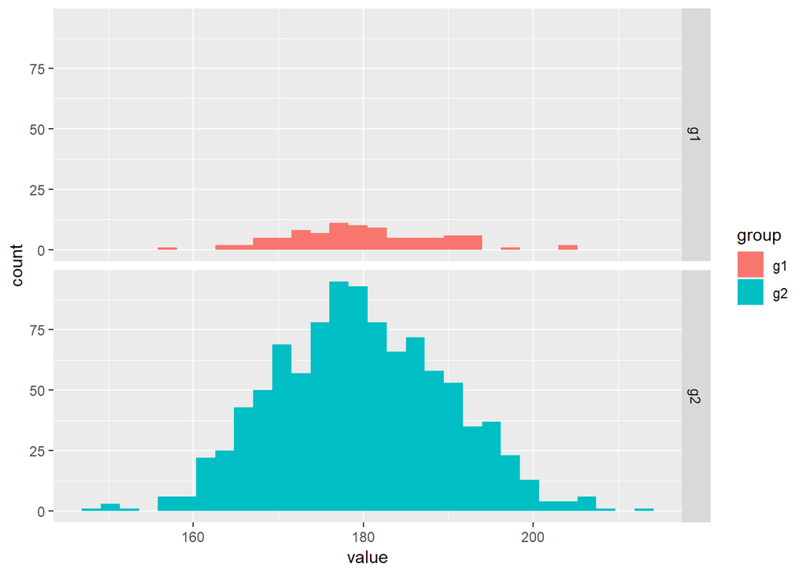

```r
ggplot(data = x, mapping = aes(x=value, fill=group)) + geom_histogram() + facet_grid(group ~.)
```

Define a function to run the simulations, since we have to do it a couple times.

```r
group_comparison_10ksim <- function(g1_mean, g1_sd, g2_mean, g2_sd, n = 10^4, test_method = t.test){
  set.seed(0)

  p_results <- vector('double', length = n)
  for (i in 1:n){
    g1 <- data.frame(group = "g1", value = rnorm(n = 90,  mean = g1_mean, sd = g1_sd ))
    g2 <- data.frame(group = "g2", value = rnorm(n = 1000,  mean = g2_mean, sd = g2_sd ))

    x <- rbind(g1,g2)

    result <- test_method(formula = value ~ group, data = x)
    p_results[[i]] <- result$p.value
  }
  result <- data.frame(p_results)
  names(result) <- 'p'
  return(result)
}
```

#### Simulate 10000 different datasets where H0 is true, test them all and collect the p values.

#### Q: Show the distribution of P values.

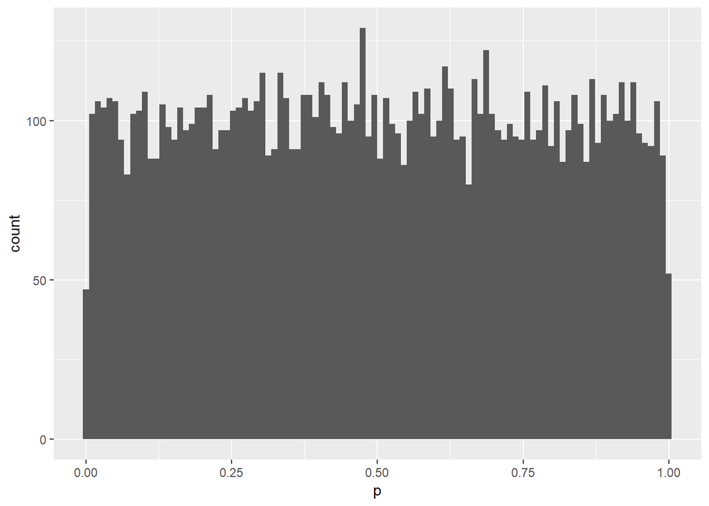

```r
p_results_true <- group_comparison_10ksim(180, 10, 180, 10)

ggplot(p_results_true, aes(x = p)) + geom_histogram(bins = 100)
```

#### Q: How many FALSE POSITIVES (alpha = 0.05) ?

```r
length(p_results_true[p_results_true < 0.05])
```

```
## [1] 505
```

#### Q: How many FALSE NEGATIVES (alpha = 0.05) ?

0, H0 is true always in our case so we don’t have type 2 errors

# What happens when H0 is FALSE?

Now we simulate that the population g2 has a different mean (185)

```r
library(tidyverse)

set.seed(0)

g1 <- data.frame(group = "g1", value = rnorm(n = 90,  mean = 180, sd = 10 ))
g2 <- data.frame(group = "g2", value = rnorm(n = 1000,  mean = 185, sd = 10 ))

x <- rbind(g1,g2)

t.test(x = g1$value, y=g2$value)
```

```
##
##  Welch Two Sample t-test
##
## data:  g1$value and g2$value
## t = -4.7894, df = 110.8, p-value = 5.217e-06
## alternative hypothesis: true difference in means is not equal to 0
## 95 percent confidence interval:
##  -6.704177 -2.780107
## sample estimates:
## mean of x mean of y
##  179.9553  184.6975
```

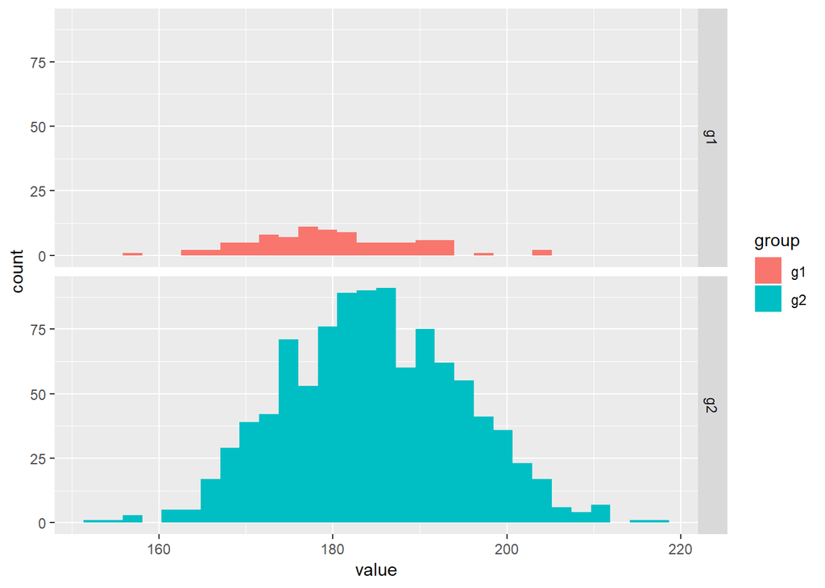

```r
ggplot(data = x, mapping = aes(x=value, fill=group)) + geom_histogram() + facet_grid(group ~.)
```

#### Simulate 10000 datasets where H0 is FALSE and test them all and collect the p values.

Use g1 (mean=180, sd=10) and g2(mean=185, sd=10)

#### Q: Show the distribution of P values.

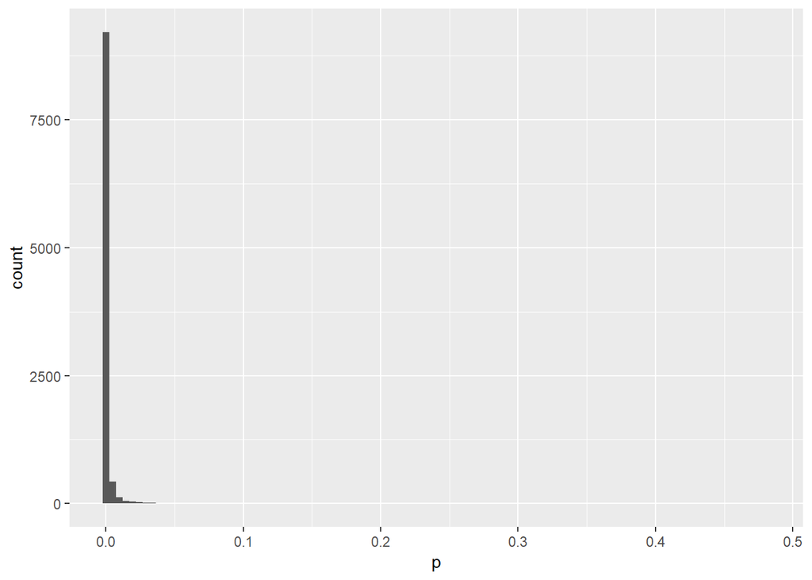

```r
library(tidyverse)

p_results_false = group_comparison_10ksim(180, 10, 185, 10)
ggplot(p_results_false, aes(x = p)) + geom_histogram(bins = 100)
```

#### Q: How many FALSE POSITIVES (alpha = 0.05) ?

0, H0 is false in our case.

#### Q: How many FALSE NEGATIVES (alpha = 0.05) ?

```r
length(p_results_false[p_results_false > 0.05])
```

```
## [1] 59
```

# Violating assumptions - different variance as example

```r
library(tidyverse)

set.seed(0)

g1 <- data.frame(group = "g1", value = rnorm(n = 90,   mean=180, sd=20))
g2 <- data.frame(group = "g2", value = rnorm(n = 1000, mean=180, sd=5))

x <- rbind(g1,g2)

t.test(x = g1$value, y=g2$value)
```

```
##
##  Welch Two Sample t-test
##
## data:  g1$value and g2$value
## t = 0.032919, df = 90.3, p-value = 0.9738
## alternative hypothesis: true difference in means is not equal to 0
## 95 percent confidence interval:
##  -3.674744  3.798582
## sample estimates:
## mean of x mean of y
##  179.9107  179.8487
```

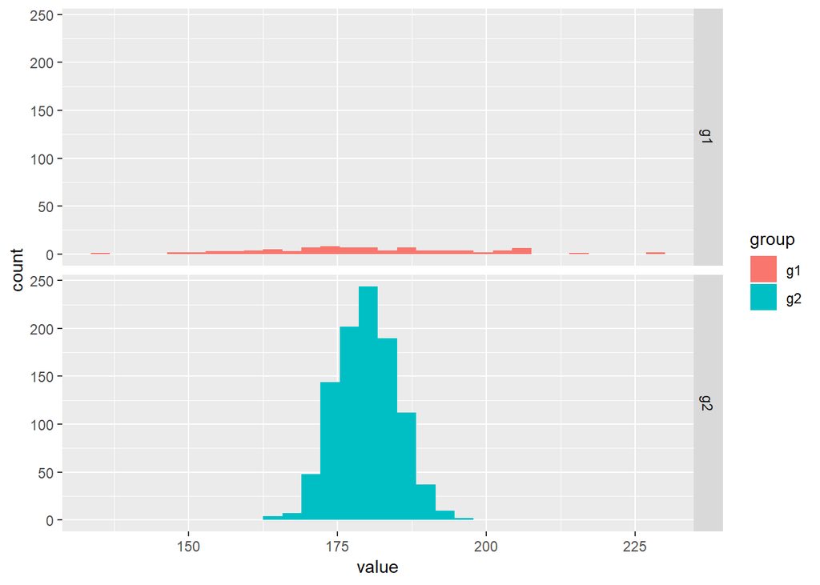

```r
ggplot(data = x, mapping = aes(x=value, fill=group)) + geom_histogram() + facet_grid(group ~.)
```

#### Simulate 10000 different datasets where H0 is true, test them all and collect the p values.

Use g1 (mean=180, sd=20) and g2(mean=180, sd=5)

#### Q: Show the distribution of P values.

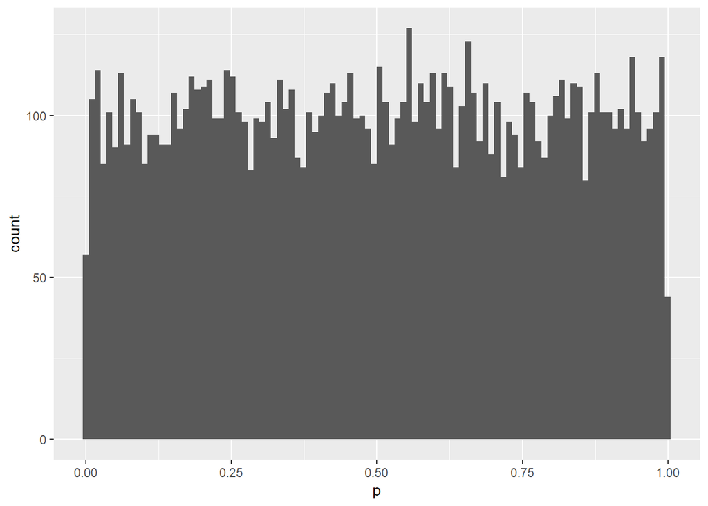

```r
library(tidyverse)


p_results_true_va = group_comparison_10ksim(180, 20, 180, 5)
ggplot(p_results_true_va, aes(x = p)) + geom_histogram(bins = 100)
```

#### Q: How many FALSE POSITIVES (alpha = 0.05) ?

```r
length(p_results_true_va[p_results_true_va < 0.05])
```

```
## [1] 505
```

#### Q:How many FALSE NEGATIVES (alpha = 0.05) ?

0

#### Simulate 10000 datasets where H0 is FALSE and test them all and collect the p values.

Use g1 (mean=180, sd=20) and g2(mean=185, sd=5)

#### Q: Show the distribution of P values.

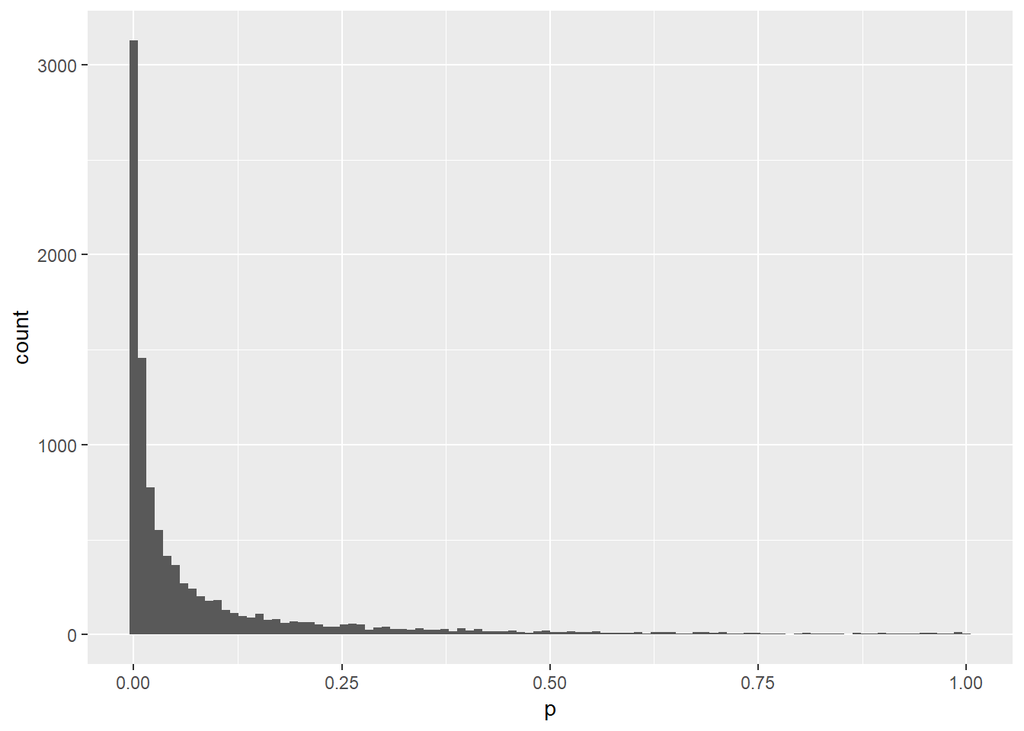

```r
library(tidyverse)

p_results_false_va = group_comparison_10ksim(180, 20, 185, 5)
ggplot(p_results_false_va, aes(x = p)) + geom_histogram(bins = 100)
```

#### Q: How many FALSE POSITIVES (alpha = 0.05) ?

0…

#### Q: How many FALSE NEGATIVES (alpha = 0.05) ?

```r
length(p_results_false_va[p_results_false_va > 0.05])
```

```
## [1] 3499
```